# Risk Factor Analysis

## Outcome Variable

**Outcome Variable:** ever_sstunted

## Predictor Variables

**Intervention Variable:** nchldlt5

**Adjustment Set:**

- arm
- W_mage
- meducyrs
- feducyrs
- hhwealth_quart
- hfoodsec
- W_mhtcm
- W_mwtkg
- W_mbmi
- W_nrooms
- W_parity
- impfloor
- impsan
- safeh20
- delta_W_mage
- delta_meducyrs
- delta_feducyrs
- delta_hhwealth_quart
- delta_hfoodsec
- delta_W_mhtcm
- delta_W_mwtkg
- delta_W_mbmi
- delta_W_nrooms
- delta_W_parity
- delta_impfloor
- delta_impsan
- delta_safeh20

## Stratifying Variables

The analysis was stratified on these variable(s):

- agecat
- studyid
- country

## Data Summary

| agecat | studyid | country | nchldlt5 | ever_sstunted | n_cell | n |
| --- | --- | --- | --- | --- | --- | --- |
| 0-24 months | iLiNS-Zinc | BURKINA FASO | 1 | 0 | 977 | 3188 |
| 0-24 months | iLiNS-Zinc | BURKINA FASO | 1 | 1 | 96 | 3188 |
| 0-24 months | iLiNS-Zinc | BURKINA FASO | 2+ | 0 | 1879 | 3188 |
| 0-24 months | iLiNS-Zinc | BURKINA FASO | 2+ | 1 | 236 | 3188 |
| 0-24 months | IRC | INDIA | 1 | 0 | 64 | 410 |
| 0-24 months | IRC | INDIA | 1 | 1 | 25 | 410 |
| 0-24 months | IRC | INDIA | 2+ | 0 | 244 | 410 |
| 0-24 months | IRC | INDIA | 2+ | 1 | 77 | 410 |
| 0-24 months | JiVitA-3 | BANGLADESH | 1 | 0 | 13936 | 27200 |
| 0-24 months | JiVitA-3 | BANGLADESH | 1 | 1 | 3474 | 27200 |
| 0-24 months | JiVitA-3 | BANGLADESH | 2+ | 0 | 8244 | 27200 |
| 0-24 months | JiVitA-3 | BANGLADESH | 2+ | 1 | 1546 | 27200 |
| 0-24 months | LCNI-5 | MALAWI | 1 | 0 | 327 | 812 |
| 0-24 months | LCNI-5 | MALAWI | 1 | 1 | 64 | 812 |
| 0-24 months | LCNI-5 | MALAWI | 2+ | 0 | 315 | 812 |
| 0-24 months | LCNI-5 | MALAWI | 2+ | 1 | 106 | 812 |
| 0-24 months | NIH-Crypto | BANGLADESH | 1 | 0 | 475 | 758 |
| 0-24 months | NIH-Crypto | BANGLADESH | 1 | 1 | 66 | 758 |
| 0-24 months | NIH-Crypto | BANGLADESH | 2+ | 0 | 184 | 758 |
| 0-24 months | NIH-Crypto | BANGLADESH | 2+ | 1 | 33 | 758 |
| 0-24 months | PROVIDE | BANGLADESH | 1 | 0 | 442 | 700 |
| 0-24 months | PROVIDE | BANGLADESH | 1 | 1 | 70 | 700 |
| 0-24 months | PROVIDE | BANGLADESH | 2+ | 0 | 163 | 700 |
| 0-24 months | PROVIDE | BANGLADESH | 2+ | 1 | 25 | 700 |
| 0-24 months | TanzaniaChild2 | TANZANIA, UNITED REPUBLIC OF | 1 | 0 | 1479 | 2385 |
| 0-24 months | TanzaniaChild2 | TANZANIA, UNITED REPUBLIC OF | 1 | 1 | 158 | 2385 |
| 0-24 months | TanzaniaChild2 | TANZANIA, UNITED REPUBLIC OF | 2+ | 0 | 669 | 2385 |
| 0-24 months | TanzaniaChild2 | TANZANIA, UNITED REPUBLIC OF | 2+ | 1 | 79 | 2385 |
| 0-6 months | IRC | INDIA | 1 | 0 | 68 | 410 |
| 0-6 months | IRC | INDIA | 1 | 1 | 21 | 410 |
| 0-6 months | IRC | INDIA | 2+ | 0 | 280 | 410 |
| 0-6 months | IRC | INDIA | 2+ | 1 | 41 | 410 |
| 0-6 months | JiVitA-3 | BANGLADESH | 1 | 0 | 14467 | 27134 |
| 0-6 months | JiVitA-3 | BANGLADESH | 1 | 1 | 2892 | 27134 |
| 0-6 months | JiVitA-3 | BANGLADESH | 2+ | 0 | 8665 | 27134 |
| 0-6 months | JiVitA-3 | BANGLADESH | 2+ | 1 | 1110 | 27134 |
| 0-6 months | LCNI-5 | MALAWI | 1 | 0 | 111 | 267 |
| 0-6 months | LCNI-5 | MALAWI | 1 | 1 | 11 | 267 |
| 0-6 months | LCNI-5 | MALAWI | 2+ | 0 | 137 | 267 |
| 0-6 months | LCNI-5 | MALAWI | 2+ | 1 | 8 | 267 |
| 0-6 months | NIH-Crypto | BANGLADESH | 1 | 0 | 506 | 758 |
| 0-6 months | NIH-Crypto | BANGLADESH | 1 | 1 | 35 | 758 |
| 0-6 months | NIH-Crypto | BANGLADESH | 2+ | 0 | 205 | 758 |
| 0-6 months | NIH-Crypto | BANGLADESH | 2+ | 1 | 12 | 758 |
| 0-6 months | PROVIDE | BANGLADESH | 1 | 0 | 488 | 700 |
| 0-6 months | PROVIDE | BANGLADESH | 1 | 1 | 24 | 700 |
| 0-6 months | PROVIDE | BANGLADESH | 2+ | 0 | 181 | 700 |
| 0-6 months | PROVIDE | BANGLADESH | 2+ | 1 | 7 | 700 |
| 0-6 months | TanzaniaChild2 | TANZANIA, UNITED REPUBLIC OF | 1 | 0 | 1564 | 2385 |
| 0-6 months | TanzaniaChild2 | TANZANIA, UNITED REPUBLIC OF | 1 | 1 | 73 | 2385 |
| 0-6 months | TanzaniaChild2 | TANZANIA, UNITED REPUBLIC OF | 2+ | 0 | 718 | 2385 |
| 0-6 months | TanzaniaChild2 | TANZANIA, UNITED REPUBLIC OF | 2+ | 1 | 30 | 2385 |

The following strata were considered:

- agecat: 0-24 months, studyid: iLiNS-Zinc, country: BURKINA FASO
- agecat: 0-24 months, studyid: IRC, country: INDIA
- agecat: 0-24 months, studyid: JiVitA-3, country: BANGLADESH
- agecat: 0-24 months, studyid: LCNI-5, country: MALAWI
- agecat: 0-24 months, studyid: NIH-Crypto, country: BANGLADESH
- agecat: 0-24 months, studyid: PROVIDE, country: BANGLADESH
- agecat: 0-24 months, studyid: TanzaniaChild2, country: TANZANIA, UNITED REPUBLIC OF
- agecat: 0-6 months, studyid: IRC, country: INDIA
- agecat: 0-6 months, studyid: JiVitA-3, country: BANGLADESH
- agecat: 0-6 months, studyid: LCNI-5, country: MALAWI
- agecat: 0-6 months, studyid: NIH-Crypto, country: BANGLADESH
- agecat: 0-6 months, studyid: PROVIDE, country: BANGLADESH
- agecat: 0-6 months, studyid: TanzaniaChild2, country: TANZANIA, UNITED REPUBLIC OF

## Methods Detail

We’re interested in the causal parameters $E[Y_a]$ for all values of $a \in \mathcal{A}$. These parameters represent the mean outcome if, possibly contrary to fact, we intervened to set all units to have $A=a$. Under the randomization and positivity assumptions, these are identified by the statistical parameters $\psi_a=E_W[E_{Y|A,W}(Y|A=a,W)]$. In addition, we’re interested in the mean of $Y$, $E[Y]$ under no intervention (the observed mean). We will estimate these parameters by using SuperLearner to fit the relevant likelihood factors – $E_{Y|A,W}(Y|A=a,W)$ and $p(A=a|W)$, and then updating our likelihood fit using a joint TMLE.

For unadjusted analyses ($W=\{\}$), initial likelihoods were estimated using Lrnr_glm to estimate the simple $E(Y|A)$ and Lrnr_mean to estimate $p(A)$. For adjusted analyses, a small library containing Lrnr_glmnet, Lrnr_xgboost, and Lrnr_mean was used.

Having estimated these parameters, we will then use the delta method to estimate relative risks and attributable risks relative to a prespecified baseline level of $A$.

# Results Detail

## Results Plots

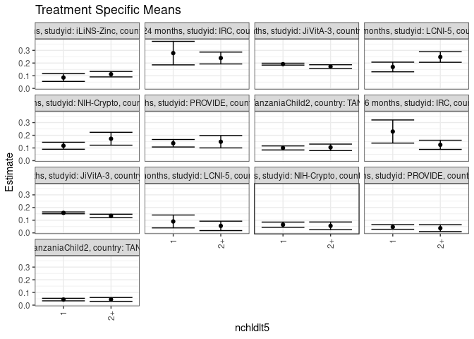

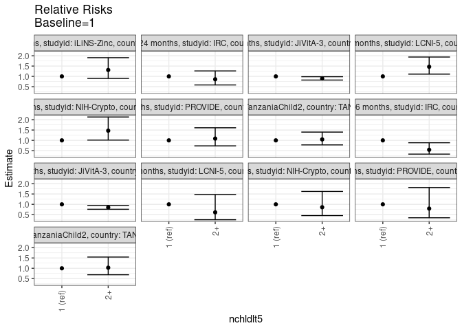

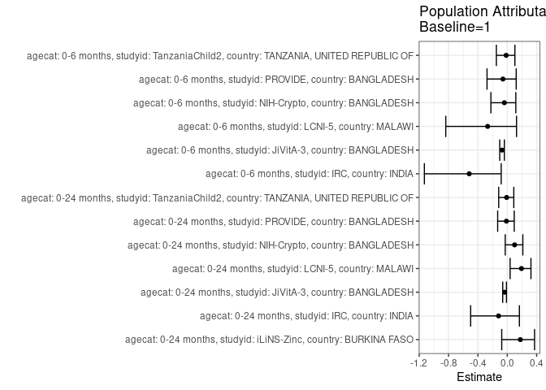

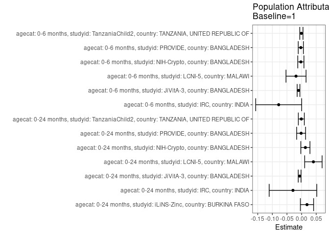

## Results Table

### Parameter: TSM

| agecat | studyid | country | intervention_level | baseline_level | estimate | ci_lower | ci_upper |
| --- | --- | --- | --- | --- | --- | --- | --- |
| 0-24 months | iLiNS-Zinc | BURKINA FASO | 1 | NA | 0.0856001 | 0.0551487 | 0.1160514 |
| 0-24 months | iLiNS-Zinc | BURKINA FASO | 2+ | NA | 0.1122270 | 0.0906688 | 0.1337852 |
| 0-24 months | IRC | INDIA | 1 | NA | 0.2782320 | 0.1854440 | 0.3710200 |
| 0-24 months | IRC | INDIA | 2+ | NA | 0.2395981 | 0.1927247 | 0.2864715 |
| 0-24 months | JiVitA-3 | BANGLADESH | 1 | NA | 0.1911882 | 0.1836843 | 0.1986921 |
| 0-24 months | JiVitA-3 | BANGLADESH | 2+ | NA | 0.1721837 | 0.1578765 | 0.1864909 |
| 0-24 months | LCNI-5 | MALAWI | 1 | NA | 0.1688962 | 0.1307952 | 0.2069973 |
| 0-24 months | LCNI-5 | MALAWI | 2+ | NA | 0.2477915 | 0.2061095 | 0.2894734 |
| 0-24 months | NIH-Crypto | BANGLADESH | 1 | NA | 0.1175506 | 0.0901347 | 0.1449666 |
| 0-24 months | NIH-Crypto | BANGLADESH | 2+ | NA | 0.1727270 | 0.1219552 | 0.2234988 |
| 0-24 months | PROVIDE | BANGLADESH | 1 | NA | 0.1372862 | 0.1076216 | 0.1669508 |
| 0-24 months | PROVIDE | BANGLADESH | 2+ | NA | 0.1490729 | 0.1003002 | 0.1978456 |
| 0-24 months | TanzaniaChild2 | TANZANIA, UNITED REPUBLIC OF | 1 | NA | 0.1002154 | 0.0842248 | 0.1162060 |
| 0-24 months | TanzaniaChild2 | TANZANIA, UNITED REPUBLIC OF | 2+ | NA | 0.1047534 | 0.0790214 | 0.1304854 |
| 0-6 months | IRC | INDIA | 1 | NA | 0.2295558 | 0.1384006 | 0.3207110 |
| 0-6 months | IRC | INDIA | 2+ | NA | 0.1248911 | 0.0887811 | 0.1610011 |
| 0-6 months | JiVitA-3 | BANGLADESH | 1 | NA | 0.1579075 | 0.1506249 | 0.1651901 |
| 0-6 months | JiVitA-3 | BANGLADESH | 2+ | NA | 0.1339795 | 0.1205349 | 0.1474240 |
| 0-6 months | LCNI-5 | MALAWI | 1 | NA | 0.0901639 | 0.0392448 | 0.1410831 |
| 0-6 months | LCNI-5 | MALAWI | 2+ | NA | 0.0551724 | 0.0179404 | 0.0924044 |
| 0-6 months | NIH-Crypto | BANGLADESH | 1 | NA | 0.0644478 | 0.0437125 | 0.0851831 |
| 0-6 months | NIH-Crypto | BANGLADESH | 2+ | NA | 0.0554131 | 0.0249297 | 0.0858965 |
| 0-6 months | PROVIDE | BANGLADESH | 1 | NA | 0.0468750 | 0.0285532 | 0.0651968 |
| 0-6 months | PROVIDE | BANGLADESH | 2+ | NA | 0.0372340 | 0.0101502 | 0.0643179 |
| 0-6 months | TanzaniaChild2 | TANZANIA, UNITED REPUBLIC OF | 1 | NA | 0.0438121 | 0.0338347 | 0.0537895 |
| 0-6 months | TanzaniaChild2 | TANZANIA, UNITED REPUBLIC OF | 2+ | NA | 0.0451024 | 0.0299939 | 0.0602109 |

### Parameter: E(Y)

| agecat | studyid | country | intervention_level | baseline_level | estimate | ci_lower | ci_upper |
| --- | --- | --- | --- | --- | --- | --- | --- |
| 0-24 months | iLiNS-Zinc | BURKINA FASO | NA | NA | 0.1041405 | 0.0842158 | 0.1240653 |
| 0-24 months | IRC | INDIA | NA | NA | 0.2487805 | 0.2068840 | 0.2906770 |
| 0-24 months | JiVitA-3 | BANGLADESH | NA | NA | 0.1845588 | 0.1789526 | 0.1901651 |
| 0-24 months | LCNI-5 | MALAWI | NA | NA | 0.2093596 | 0.1813586 | 0.2373606 |
| 0-24 months | NIH-Crypto | BANGLADESH | NA | NA | 0.1306069 | 0.1066024 | 0.1546113 |
| 0-24 months | PROVIDE | BANGLADESH | NA | NA | 0.1357143 | 0.1103250 | 0.1611036 |
| 0-24 months | TanzaniaChild2 | TANZANIA, UNITED REPUBLIC OF | NA | NA | 0.0993711 | 0.0873623 | 0.1113798 |
| 0-6 months | IRC | INDIA | NA | NA | 0.1512195 | 0.1164988 | 0.1859402 |
| 0-6 months | JiVitA-3 | BANGLADESH | NA | NA | 0.1474902 | 0.1424375 | 0.1525429 |
| 0-6 months | LCNI-5 | MALAWI | NA | NA | 0.0711610 | 0.0402653 | 0.1020568 |
| 0-6 months | NIH-Crypto | BANGLADESH | NA | NA | 0.0620053 | 0.0448256 | 0.0791849 |
| 0-6 months | PROVIDE | BANGLADESH | NA | NA | 0.0442857 | 0.0290345 | 0.0595370 |
| 0-6 months | TanzaniaChild2 | TANZANIA, UNITED REPUBLIC OF | NA | NA | 0.0431866 | 0.0350267 | 0.0513464 |

### Parameter: RR

| agecat | studyid | country | intervention_level | baseline_level | estimate | ci_lower | ci_upper |
| --- | --- | --- | --- | --- | --- | --- | --- |
| 0-24 months | iLiNS-Zinc | BURKINA FASO | 1 | 1 | 1.0000000 | 1.0000000 | 1.0000000 |
| 0-24 months | iLiNS-Zinc | BURKINA FASO | 2+ | 1 | 1.3110623 | 0.9015531 | 1.9065812 |
| 0-24 months | IRC | INDIA | 1 | 1 | 1.0000000 | 1.0000000 | 1.0000000 |
| 0-24 months | IRC | INDIA | 2+ | 1 | 0.8611449 | 0.5859863 | 1.2655084 |
| 0-24 months | JiVitA-3 | BANGLADESH | 1 | 1 | 1.0000000 | 1.0000000 | 1.0000000 |
| 0-24 months | JiVitA-3 | BANGLADESH | 2+ | 1 | 0.9005979 | 0.8230306 | 0.9854757 |
| 0-24 months | LCNI-5 | MALAWI | 1 | 1 | 1.0000000 | 1.0000000 | 1.0000000 |
| 0-24 months | LCNI-5 | MALAWI | 2+ | 1 | 1.4671224 | 1.1107458 | 1.9378406 |
| 0-24 months | NIH-Crypto | BANGLADESH | 1 | 1 | 1.0000000 | 1.0000000 | 1.0000000 |
| 0-24 months | NIH-Crypto | BANGLADESH | 2+ | 1 | 1.4693838 | 1.0128259 | 2.1317471 |
| 0-24 months | PROVIDE | BANGLADESH | 1 | 1 | 1.0000000 | 1.0000000 | 1.0000000 |
| 0-24 months | PROVIDE | BANGLADESH | 2+ | 1 | 1.0858551 | 0.7327473 | 1.6091240 |
| 0-24 months | TanzaniaChild2 | TANZANIA, UNITED REPUBLIC OF | 1 | 1 | 1.0000000 | 1.0000000 | 1.0000000 |
| 0-24 months | TanzaniaChild2 | TANZANIA, UNITED REPUBLIC OF | 2+ | 1 | 1.0452824 | 0.7800848 | 1.4006366 |
| 0-6 months | IRC | INDIA | 1 | 1 | 1.0000000 | 1.0000000 | 1.0000000 |
| 0-6 months | IRC | INDIA | 2+ | 1 | 0.5440555 | 0.3344774 | 0.8849518 |
| 0-6 months | JiVitA-3 | BANGLADESH | 1 | 1 | 1.0000000 | 1.0000000 | 1.0000000 |
| 0-6 months | JiVitA-3 | BANGLADESH | 2+ | 1 | 0.8484683 | 0.7599163 | 0.9473391 |
| 0-6 months | LCNI-5 | MALAWI | 1 | 1 | 1.0000000 | 1.0000000 | 1.0000000 |
| 0-6 months | LCNI-5 | MALAWI | 2+ | 1 | 0.6119122 | 0.2538214 | 1.4751968 |
| 0-6 months | NIH-Crypto | BANGLADESH | 1 | 1 | 1.0000000 | 1.0000000 | 1.0000000 |
| 0-6 months | NIH-Crypto | BANGLADESH | 2+ | 1 | 0.8598136 | 0.4551901 | 1.6241116 |
| 0-6 months | PROVIDE | BANGLADESH | 1 | 1 | 1.0000000 | 1.0000000 | 1.0000000 |
| 0-6 months | PROVIDE | BANGLADESH | 2+ | 1 | 0.7943262 | 0.3478373 | 1.8139348 |
| 0-6 months | TanzaniaChild2 | TANZANIA, UNITED REPUBLIC OF | 1 | 1 | 1.0000000 | 1.0000000 | 1.0000000 |
| 0-6 months | TanzaniaChild2 | TANZANIA, UNITED REPUBLIC OF | 2+ | 1 | 1.0294515 | 0.6867778 | 1.5431052 |

### Parameter: PAR

| agecat | studyid | country | intervention_level | baseline_level | estimate | ci_lower | ci_upper |
| --- | --- | --- | --- | --- | --- | --- | --- |
| 0-24 months | iLiNS-Zinc | BURKINA FASO | 1 | NA | 0.0185405 | -0.0041115 | 0.0411925 |
| 0-24 months | IRC | INDIA | 1 | NA | -0.0294515 | -0.1108932 | 0.0519901 |
| 0-24 months | JiVitA-3 | BANGLADESH | 1 | NA | -0.0066294 | -0.0113928 | -0.0018660 |
| 0-24 months | LCNI-5 | MALAWI | 1 | NA | 0.0404634 | 0.0106603 | 0.0702664 |
| 0-24 months | NIH-Crypto | BANGLADESH | 1 | NA | 0.0130562 | -0.0025862 | 0.0286986 |
| 0-24 months | PROVIDE | BANGLADESH | 1 | NA | -0.0015719 | -0.0168503 | 0.0137064 |
| 0-24 months | TanzaniaChild2 | TANZANIA, UNITED REPUBLIC OF | 1 | NA | -0.0008443 | -0.0110469 | 0.0093582 |
| 0-6 months | IRC | INDIA | 1 | NA | -0.0783363 | -0.1569452 | 0.0002727 |
| 0-6 months | JiVitA-3 | BANGLADESH | 1 | NA | -0.0104172 | -0.0150899 | -0.0057445 |
| 0-6 months | LCNI-5 | MALAWI | 1 | NA | -0.0190029 | -0.0533233 | 0.0153176 |
| 0-6 months | NIH-Crypto | BANGLADESH | 1 | NA | -0.0024425 | -0.0129399 | 0.0080549 |
| 0-6 months | PROVIDE | BANGLADESH | 1 | NA | -0.0025893 | -0.0113770 | 0.0061984 |
| 0-6 months | TanzaniaChild2 | TANZANIA, UNITED REPUBLIC OF | 1 | NA | -0.0006255 | -0.0060636 | 0.0048126 |

### Parameter: PAF

| agecat | studyid | country | intervention_level | baseline_level | estimate | ci_lower | ci_upper |
| --- | --- | --- | --- | --- | --- | --- | --- |
| 0-24 months | iLiNS-Zinc | BURKINA FASO | 1 | NA | 0.1780332 | -0.0752721 | 0.3716665 |
| 0-24 months | IRC | INDIA | 1 | NA | -0.1183835 | -0.4986425 | 0.1653902 |
| 0-24 months | JiVitA-3 | BANGLADESH | 1 | NA | -0.0359202 | -0.0620320 | -0.0104504 |
| 0-24 months | LCNI-5 | MALAWI | 1 | NA | 0.1932720 | 0.0388662 | 0.3228726 |
| 0-24 months | NIH-Crypto | BANGLADESH | 1 | NA | 0.0999658 | -0.0278091 | 0.2118560 |
| 0-24 months | PROVIDE | BANGLADESH | 1 | NA | -0.0115826 | -0.1306804 | 0.0949704 |
| 0-24 months | TanzaniaChild2 | TANZANIA, UNITED REPUBLIC OF | 1 | NA | -0.0084967 | -0.1165477 | 0.0890980 |
| 0-6 months | IRC | INDIA | 1 | NA | -0.5180302 | -1.1287211 | -0.0825353 |
| 0-6 months | JiVitA-3 | BANGLADESH | 1 | NA | -0.0706299 | -0.1025799 | -0.0396057 |
| 0-6 months | LCNI-5 | MALAWI | 1 | NA | -0.2670406 | -0.8374155 | 0.1262772 |
| 0-6 months | NIH-Crypto | BANGLADESH | 1 | NA | -0.0393920 | -0.2227954 | 0.1165033 |
| 0-6 months | PROVIDE | BANGLADESH | 1 | NA | -0.0584677 | -0.2756059 | 0.1217084 |
| 0-6 months | TanzaniaChild2 | TANZANIA, UNITED REPUBLIC OF | 1 | NA | -0.0144840 | -0.1484687 | 0.1038695 |